# lab10_HamnaAshraf

### Lab 10:

#### Hamna Ashraf - 8826836

Required Libraries:

```python
import os, shutil, pathlib
import re
import matplotlib.pyplot as plt
import numpy as np
import seaborn as sns
import cv2
import pandas as pd
from tensorflow import keras
from tensorflow.keras import layers
from tensorflow.keras.utils import image_dataset_from_directory
from keras.models import load_model
from sklearn.metrics import classification_report, confusion_matrix
```

### Obtain data:

```python
original_dir = pathlib.Path("../data/kaggle_dogs_vs_cats/train")
new_base_dir = pathlib.Path("../data/kaggle_dogs_vs_cats_small")

def make_subset(subset_name, start_index, end_index):
    for category in ("cat", "dog"):
        dir = new_base_dir / subset_name / category
        os.makedirs(dir)
        fnames = [f"{category}.{i}.jpg" for i in range(start_index, end_index)]
        for fname in fnames:
            shutil.copyfile(src=original_dir / fname,
                            dst=dir / fname)

make_subset("train", start_index=0, end_index=1000)
make_subset("validation", start_index=1000, end_index=1500)
make_subset("test", start_index=1500, end_index=2500)
```

### Exploratory Data Analysis (EDA):

```python
total_count = len(os.listdir('../data/kaggle_dogs_vs_cats/train'))
print(f'Number of samples in train folder : {total_count}')

cat_count, dog_count = 0, 0
for file_name in os.listdir('../data/kaggle_dogs_vs_cats/train') :
    cat = re.findall("\Acat", file_name)
    dog = re.findall("\Adog", file_name)
    if cat :
        cat_count+=1
    if dog :
        dog_count+=1

total_count = [cat_count, dog_count]
```

```
Number of samples in train folder : 25000
```

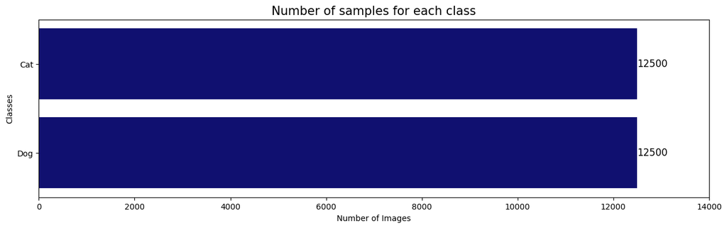

```python
plt.figure(figsize=(15, 4))
ax = sns.barplot(x=total_count, y=['Cat', 'Dog'], orient='h', color='navy')
ax.set_xticks(np.arange(0, 14500, 2000))
ax.set_xlabel('Number of Images')
ax.set_ylabel('Classes')
ax.set_title('Number of samples for each class', fontsize=15)
for i, p in enumerate(ax.patches) :
    ax.text(p.get_width(), p.get_y() + p.get_height() / 2.,
            '{}'.format(total_count[i]),
             va="center", fontsize=12)
```

In total we have 25000 images downloaded from kaggle https://www.kaggle.com/datasets/biaiscience/dogs-vs-cats/data.%5C Total cat and dog images are 12,500 each.

**Let's print 6 cats and dogs images:**

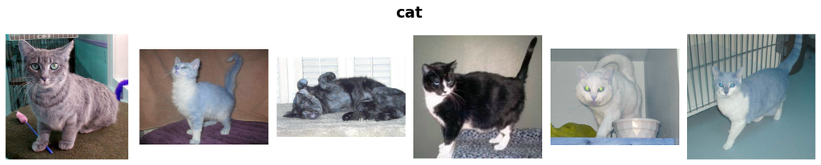

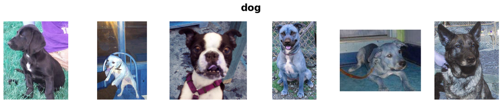

```python
temp_df = []
for file_name in os.listdir('../data/kaggle_dogs_vs_cats/train') :
    if re.findall("\Acat", file_name) :
        class_name = 'cat'
    else :
        class_name = 'dog'
    temp_df.append((os.path.join('../data/kaggle_dogs_vs_cats/train', file_name), class_name))

#create data frame df
df = pd.DataFrame(temp_df, columns=['file_path', 'label'])

def plot_6_image(images, title) :
    plt.figure(figsize=(15, 3))
    for i, path in enumerate(images) :
        plt.subplot(1, 6, i+1)
        img = cv2.imread(path)
        plt.imshow(img)
        plt.axis('off')
    plt.suptitle(title, fontsize=20, fontweight='bold')
    plt.tight_layout()
    plt.show()

# Setting the random seed for reproducibility
np.random.seed(42)

for classes in ['cat', 'dog'] :
    temp_df = df.file_path[df.label==classes]
    random_image = np.random.choice(temp_df, 6)
    plot_6_image(random_image, classes)
```

These images of cats and dogs are taken from different angles.  
Not only that, there are different breeds of both. This shows that our dataset has different kinds of cats and dogs and shows different angles of them.

**Let's check the max and min dimensions of images:**

```python
def image_size(train_folder) :
    height = []
    width = []

    unique_dims = set()

    for file_name in os.listdir(train_folder) :
        img_path = os.path.join(train_folder, file_name)
        img = cv2.imread(img_path)
        if img is not None :
            unique_dims.add((img.shape[0], img.shape[1]))
            #
            width.append(img.shape[0])
            height.append(img.shape[1])

    if len(unique_dims)==1 :
        print(f'All images have a unique shape of {list(unique_dims)[0]}')
    else :
        print(f'There are {len(unique_dims)} different image dimensions')
        print(f'Min height is {min(height)}, Min width is {min(width)}')
        print(f'Max height is {max(height)}, Max width is {max(width)}')

image_size('../data/kaggle_dogs_vs_cats/train')
```

```
There are 8513 different image dimensions
Min height is 42, Min width is 32
Max height is 1050, Max width is 768
```

### Train two networks:

**Neural Network (CNN):**

```python
inputs = keras.Input(shape=(180, 180, 3))
x = layers.Rescaling(1./255)(inputs)
x = layers.Conv2D(filters=32, kernel_size=3, activation="relu")(x)
x = layers.MaxPooling2D(pool_size=2)(x)
x = layers.Conv2D(filters=64, kernel_size=3, activation="relu")(x)
x = layers.MaxPooling2D(pool_size=2)(x)
x = layers.Conv2D(filters=128, kernel_size=3, activation="relu")(x)
x = layers.MaxPooling2D(pool_size=2)(x)
x = layers.Conv2D(filters=256, kernel_size=3, activation="relu")(x)
x = layers.MaxPooling2D(pool_size=2)(x)
x = layers.Conv2D(filters=256, kernel_size=3, activation="relu")(x)
x = layers.Flatten()(x)
outputs = layers.Dense(1, activation="sigmoid")(x)
model = keras.Model(inputs=inputs, outputs=outputs)
```

In this convnet, we will see a progressive increase in the model from 32 to 256.  
We divide by 255 to change range from 0 - 255 to 0 - 1.  
This is just like a binary classification problem where at the end the model has a single unit which is a Dense layer of size 1, and a sigmoid activation. It will encode the probability that the model is looking at one class or the other.

```python
model.summary()
```

[output not shown]

The total number of trainable parameters is a large number of almost a million.

```python
model.compile(loss="binary_crossentropy",
              optimizer="rmsprop",
              metrics=["accuracy"])
```

```python
train_dataset = image_dataset_from_directory(
    '../data/kaggle_dogs_vs_cats_small/train',
    image_size=(180, 180),
    batch_size=32)
validation_dataset = image_dataset_from_directory(
    '../data/kaggle_dogs_vs_cats_small/validation',
    image_size=(180, 180),
    batch_size=32)
test_dataset = image_dataset_from_directory(
    '../data/kaggle_dogs_vs_cats_small/test',
    image_size=(180, 180),
    batch_size=32)
```

```
Found 2000 files belonging to 2 classes.
Found 1000 files belonging to 2 classes.
Found 2000 files belonging to 2 classes.
```

```python
callbacks = [
    keras.callbacks.ModelCheckpoint(
        filepath="convnet_from_scratch.keras",
        save_best_only=True,
        monitor="val_loss")
]
history = model.fit(
    train_dataset,
    epochs=30,
    validation_data=validation_dataset,
    callbacks=callbacks)
```

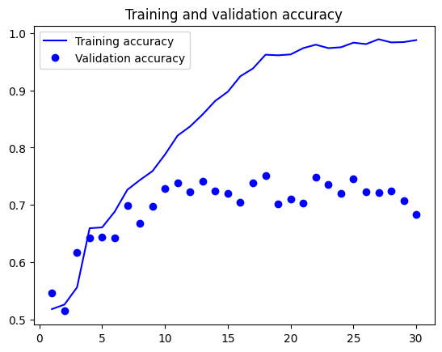

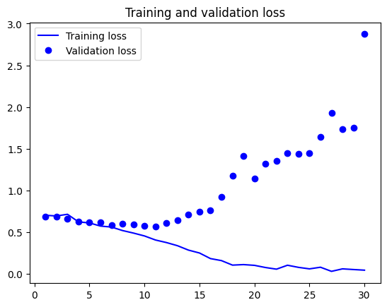

```python
accuracy = history.history["accuracy"]
val_accuracy = history.history["val_accuracy"]
loss = history.history["loss"]
val_loss = history.history["val_loss"]
epochs = range(1, len(accuracy) + 1)
plt.plot(epochs, accuracy, "b", label="Training accuracy")
plt.plot(epochs, val_accuracy, "bo", label="Validation accuracy")
plt.title("Training and validation accuracy")
plt.legend()
plt.figure()
plt.plot(epochs, loss, "b", label="Training loss")
plt.plot(epochs, val_loss, "bo", label="Validation loss")
plt.title("Training and validation loss")
plt.legend()
plt.show()
```

```python
best_cnn = load_model('convnet_from_scratch.keras')
```

**Model Accuracy:**

```python
result = best_cnn.evaluate(test_dataset)
print(f'CNN model\nAccuracy: {round(result[1], 3)}')
```

```
CNN model
Accuracy: 0.725
```

**Accurcy, Precision, Recall, F1-Score, Confusion matrix: (CNN Model)**

```python
temp_df1 = []
for file_name in os.listdir('../data/kaggle_dogs_vs_cats_small/test/cat') :
    if re.findall("\Acat", file_name) :
        class_name = 0
    temp_df1.append((os.path.join('../data/kaggle_dogs_vs_cats_small/test/cat', file_name), class_name))

for file_name in os.listdir('../data/kaggle_dogs_vs_cats_small/test/dog') :
    if re.findall("\Adog", file_name) :
        class_name = 1
    temp_df1.append((os.path.join('../data/kaggle_dogs_vs_cats_small/test/dog', file_name), class_name))


df1 = pd.DataFrame(temp_df1, columns=['file_path', 'label'])
```

```python
y_true = df1['label'].values
y_true
```

```
array([0, 0, 0, ..., 1, 1, 1], dtype=int64)
```

```python
test_dataset_temp = image_dataset_from_directory(
    '../data/kaggle_dogs_vs_cats_small/test',
    image_size=(180, 180),
    batch_size=32,
    shuffle = False)
```

```
Found 2000 files belonging to 2 classes.
```

We want to compare the predicted and actual values, therefore shuffle is set to false

```python
actual_labels = []
for images, labels in test_dataset_temp.unbatch():  # unbatch() returns individual items
    actual_labels.append(labels.numpy())

class_names = ['Cat', 'Dog']
actual_class_names = [class_names[label] for label in actual_labels]
y_true = [1 if animal == "Dog" else 0 for animal in actual_class_names]
```

```python
predictions = best_cnn.predict(test_dataset_temp)
```

```python
y_pred = np.round(predictions).astype(int).flatten()
y_pred
```

```
array([0, 1, 0, ..., 1, 1, 0])
```

```python
# Confusion Matrix
cm = confusion_matrix(y_true, y_pred)
print("Confusion Matrix:")
print(cm)

# Classification Report (Precision, Recall, F1-score)
report = classification_report(y_true, y_pred, target_names=['Cat', 'Dog'])
print("Classification Report:")
print(report)
```

```
Confusion Matrix:
[[685 315]
 [235 765]]
Classification Report:
              precision    recall  f1-score   support

         Cat       0.74      0.69      0.71      1000
         Dog       0.71      0.77      0.74      1000

    accuracy                           0.73      2000
   macro avg       0.73      0.73      0.72      2000
weighted avg       0.73      0.72      0.72      2000
```

This report shows that cat prediction is 71% correct.

#### Fine Tunning VGG-16:

Steps:

- Download model (VGG)
- Freeze layers
- Define and train model
- (For fine-tuning) unfreeze some layers in the base network.
- Evaluate the model

Freezing a layer or set of layers prevents their weights from being updated during training.

```python
conv_base = keras.applications.vgg16.VGG16(
    weights="imagenet",
    include_top=False,
    input_shape=(180, 180, 3))
```

```
Downloading data from https://storage.googleapis.com/tensorflow/keras-applications/vgg16/vgg16_weights_tf_dim_ordering_tf_kernels_notop.h5
```

```python
conv_base.trainable = False #FREEZE layers
```

```python
data_augmentation = keras.Sequential(
    [
        layers.RandomFlip("horizontal"),
        layers.RandomRotation(0.1),
        layers.RandomZoom(0.2),
    ]
)
#define input
inputs = keras.Input(shape=(180, 180, 3))
x = data_augmentation(inputs)
#preprocessing
x = keras.applications.vgg16.preprocess_input(x)
x = conv_base(x)
x = layers.Flatten()(x)
#fully connected with previous layer
x = layers.Dense(256)(x)
x = layers.Dropout(0.5)(x)
outputs = layers.Dense(1, activation="sigmoid")(x)
#chain that starts from input and goes till the output
model1 = keras.Model(inputs, outputs)
```

```python
model1.summary()
```

[output not shown]

```python
model1.compile(loss="binary_crossentropy",
              optimizer="rmsprop",
              metrics=["accuracy"])
```

```python
callbacks_vgg = [
    keras.callbacks.ModelCheckpoint(
        filepath="../models/vgg16.keras",
        save_best_only=True,
        monitor="val_loss")
]
```

```python
history = model1.fit(
    train_dataset,
    epochs= 30,
    validation_data=validation_dataset,
    callbacks=callbacks_vgg)
```

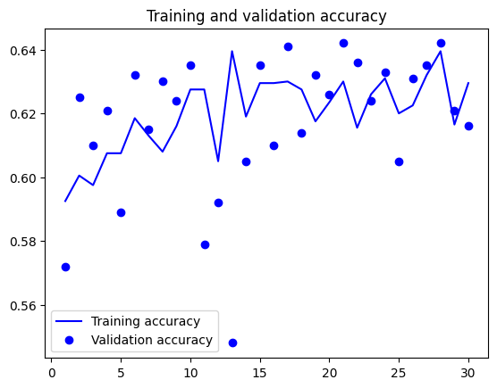

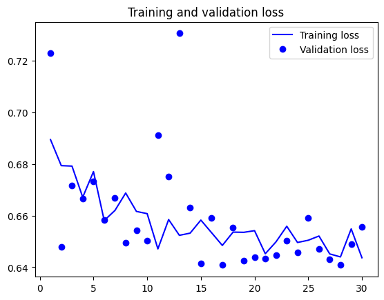

```python
acc = history.history["accuracy"]
val_acc = history.history["val_accuracy"]
loss = history.history["loss"]
val_loss = history.history["val_loss"]
epochs = range(1, len(acc) + 1)
plt.plot(epochs, acc, "b", label="Training accuracy")
plt.plot(epochs, val_acc, "bo", label="Validation accuracy")
plt.title("Training and validation accuracy")
plt.legend()
plt.figure()
plt.plot(epochs, loss, "b", label="Training loss")
plt.plot(epochs, val_loss, "bo", label="Validation loss")
plt.title("Training and validation loss")
plt.legend()
plt.show()
```

By the values we got, we can say that vgg-model didn't perform very well as it's accuracy is in range of 60-63%.  
In these graphs we can see that the validation accuracy was highest at epochs 17.

```python
test_bestmodel_vgg = keras.models.load_model(
    "../models/vgg16.keras")
test_loss, test_acc = test_bestmodel_vgg.evaluate(test_dataset)
print(f"Test accuracy: {test_acc:.3f}")
```

```
Test accuracy: 0.637
```

The test accuracy for this model is lower than what we had for the CNN model which was almost 73%

#### Fine Tuning model:

```python
conv_base.trainable = True #unfreeze layers
for layer in conv_base.layers[:-4]:
    layer.trainable = False #FREEZE except some base network layers
```

```python
model1.summary()
```

[output not shown]

```python
model1.compile(loss="binary_crossentropy",
              optimizer=keras.optimizers.RMSprop(learning_rate=1e-5),
              metrics=["accuracy"])

callbacks = [
    keras.callbacks.ModelCheckpoint(
        filepath="./models/fine_tuning_vgg.keras",
        save_best_only=True,
        monitor="val_loss")
]
history = model1.fit(
    train_dataset,
    epochs=30,
    validation_data=validation_dataset,
    callbacks=callbacks)
```

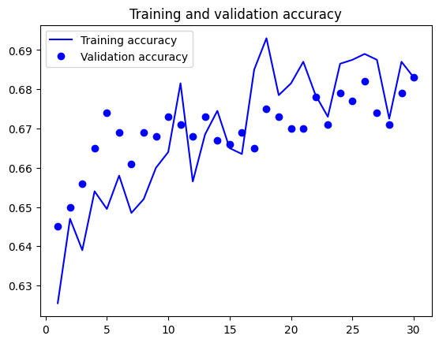

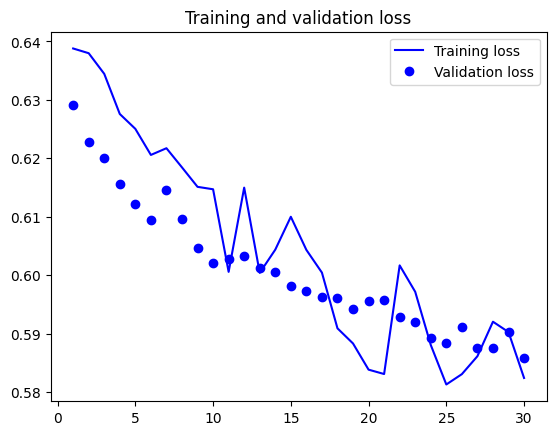

```python
acc = history.history["accuracy"]
val_acc = history.history["val_accuracy"]
loss = history.history["loss"]
val_loss = history.history["val_loss"]
epochs = range(1, len(acc) + 1)
plt.plot(epochs, acc, "b", label="Training accuracy")
plt.plot(epochs, val_acc, "bo", label="Validation accuracy")
plt.title("Training and validation accuracy")
plt.legend()
plt.figure()
plt.plot(epochs, loss, "b", label="Training loss")
plt.plot(epochs, val_loss, "bo", label="Validation loss")
plt.title("Training and validation loss")
plt.legend()
plt.show()
```

After fine-tuning the model, we can see that there is an increase in model accuracy and validation data accuracy.  
However, the overall accuracy is still less than what we got for previous CNN neural network defined.

**Fine Tuning VGG model performance:**

```python
fine_tune_vgg = load_model('../models/fine_tuning_vgg.keras')
```

```python
test_loss, test_acc = fine_tune_vgg.evaluate(test_dataset)
print(f"Test accuracy: {test_acc:.3f}")
```

```
Test accuracy: 0.684
```

The accuracy of model on test data is 68%

**Accurcy, Precision, Recall, F1-Score, Confusion matrix: (VGG fine tuned Model)**

```python
predictions = fine_tune_vgg.predict(test_dataset_temp)
```

```python
y_pred = np.round(predictions).astype(int).flatten()

# Confusion Matrix
cm = confusion_matrix(y_true, y_pred)
print("Confusion Matrix:")
print(cm)

# Classification Report (Precision, Recall, F1-score)
report = classification_report(y_true, y_pred, target_names=['Cat', 'Dog'])
print("Classification Report:")
print(report)
```

```
Confusion Matrix:
[[680 320]
 [312 688]]
Classification Report:
              precision    recall  f1-score   support

         Cat       0.69      0.68      0.68      1000
         Dog       0.68      0.69      0.69      1000

    accuracy                           0.68      2000
   macro avg       0.68      0.68      0.68      2000
weighted avg       0.68      0.68      0.68      2000
```

#### Conclusion:

After checking the accuracy, precision, recall and f1-score, we conclude that the accuracy of CNN neural network performs better than the VGG fine-tuned model.  
CNN gave us better accuracy of almost 73% where as the best parameter values we could get after VGG16-fined tuning was 68%. Therefore, we for our dataset dog vs cat, we can use the model which gives us better performance which in this case is CNN.

#### References:

https://www.kaggle.com/code/nimapourmoradi/cats-vs-dogs-fullversion  
https://learning.oreilly.com/library/view/deep-learning-with/9781617296864/Text/08.htm#heading_id_14 https://github.com/HamnaAshraf1/CSCN8010/blob/main/dl_class_notebooks/05D_fine_tuning_vgg16.ipynb